# Analyse des simulations

Parc naturel régional du Massif des Bauges

Raphaël Aussenac, Jean-Matthieu MONNET

8 juin 2020

# Introduction

L’objectif de ce document est de présenter les résultats de simulation réalisées par le logiciel SIMMEM sur le territoire du PNR du Massif des Bauges.

La première partie décrit les conditions initiales du territoire simulé. Le deuxième partie décrit les itinéraires simulés

Le nombre de polygones simulés est de 26655, pour une surface totale de 52570 ha. Leurs caractéristiques sont présentées dans les paragraphes suivants.

# 1 Description générale du territoire

## 1.1 Typologie des polygones

La typologie des peuplements résulte d’un croisement entre la propriété (qui oriente partiellement la sylviculture) et la composition en essence (qui détermine le paramétrage de la croissance et oriente partiellement la sylviculture).

Les types de polygones sont présentés sur les graphiques suivants.

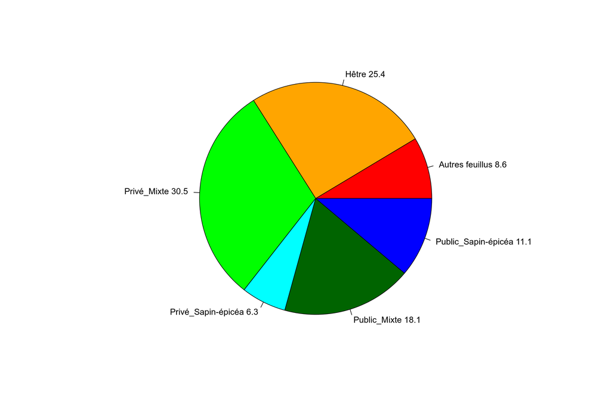

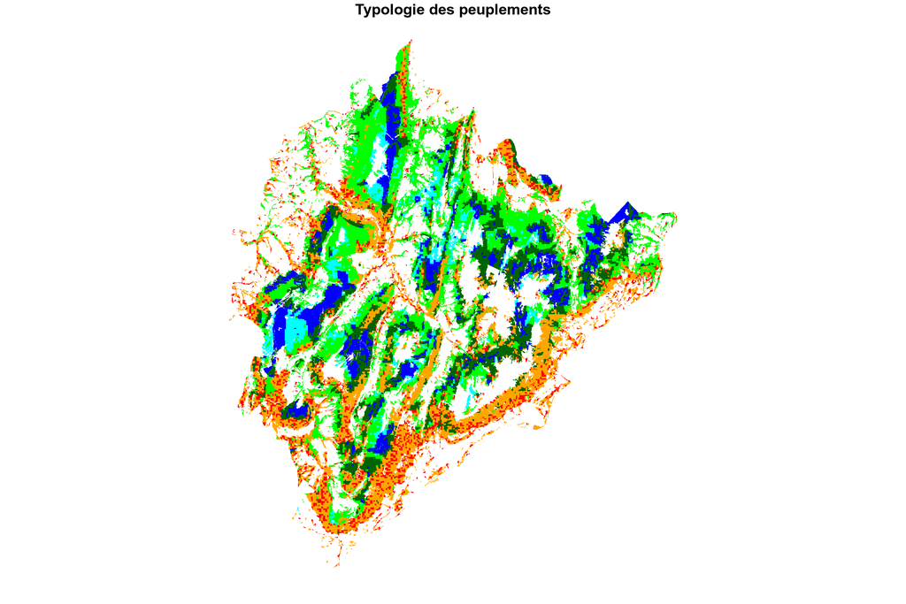

## 1.2 Accessibilité et gestion

Selon les conditions d’accessibilité du polygone, la propriété et la surface moyenne des parcelles cadastrales qu’il contient (pour la propriété privée), il peut être géré ou non.

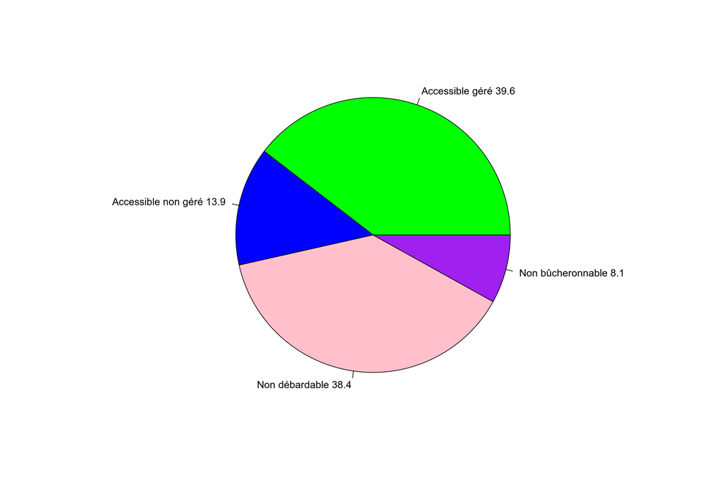

La répartition des catégories de peuplements selon la gestion (ou non) est présentée dans les figures ci-dessous.

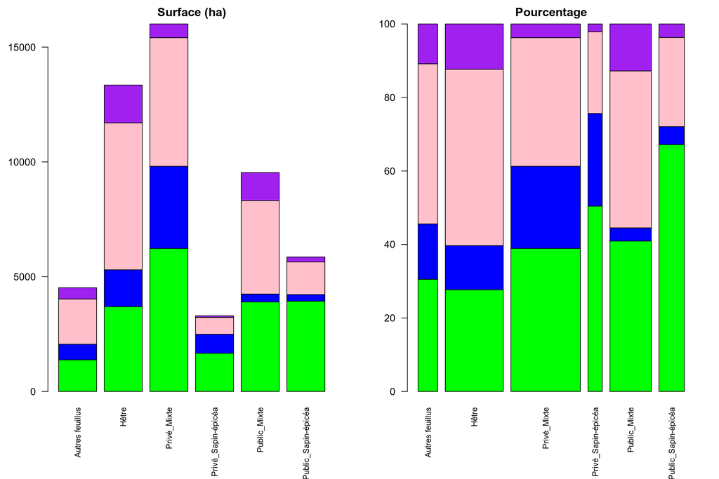

## 1.3 Itinéraires sylvicoles

Selon la catégorie du polygone, il lui est appliqué un itinéraire sylvicole. Ceux-ci sont présentés ensuite.

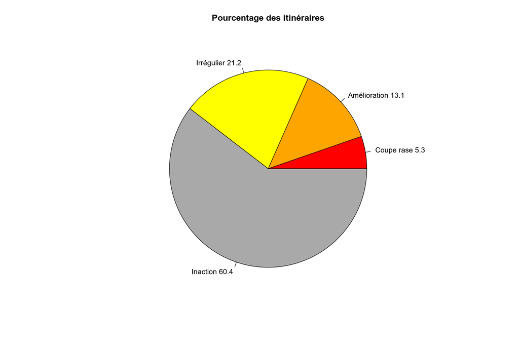

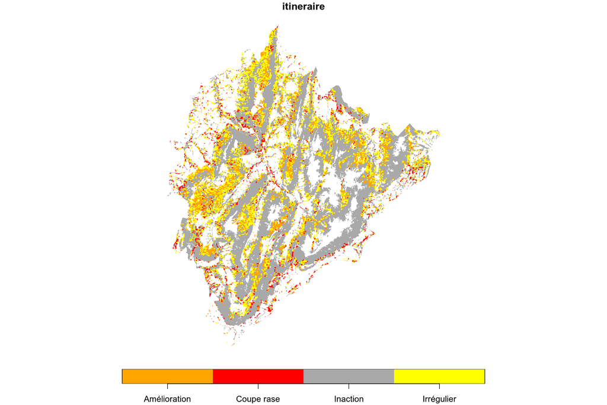

La répartition des itinéraires par catégorie de polygone figure ci-dessous.

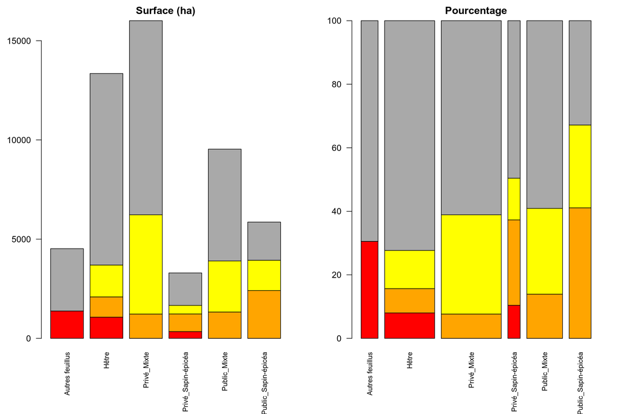

## 1.4 Dendrométrie des polygones par itinéraire et catégorie de peuplement

Les graphiques suivants montrent les valeurs initiales de RDI et Dg pour les itinéraires et sous-itinéraires appliqués aux différentes catégories de peuplement.

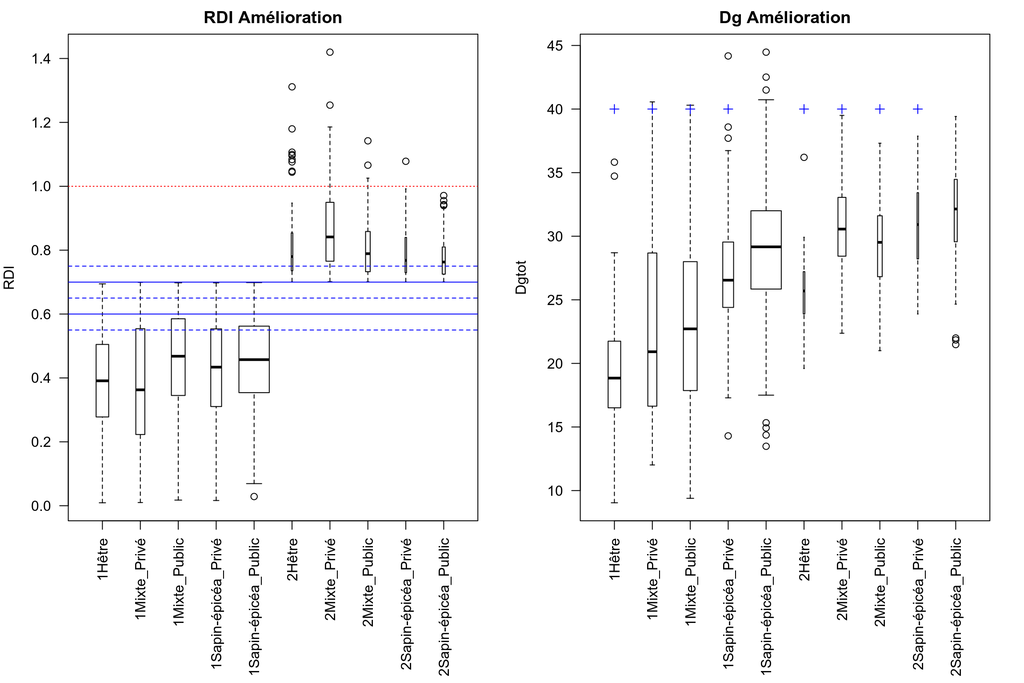

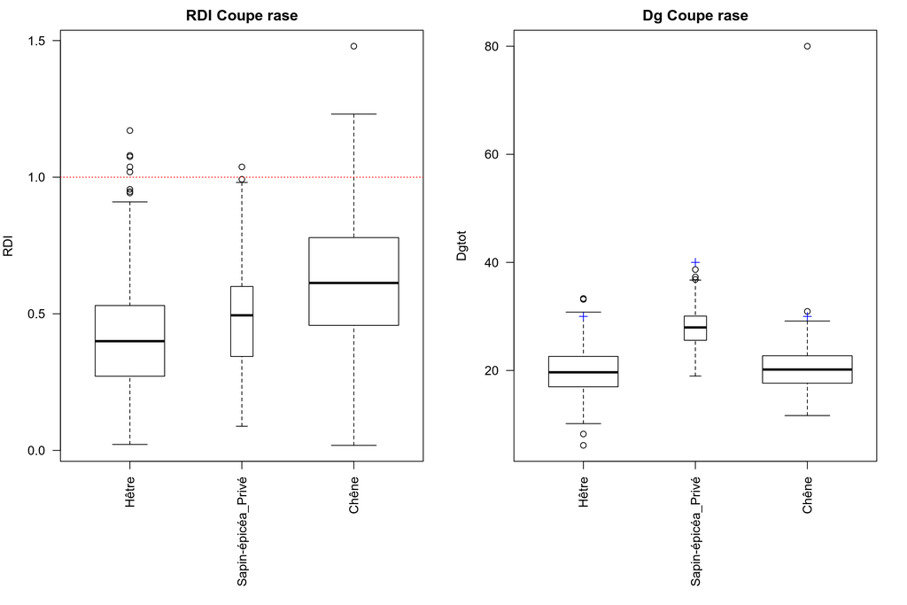

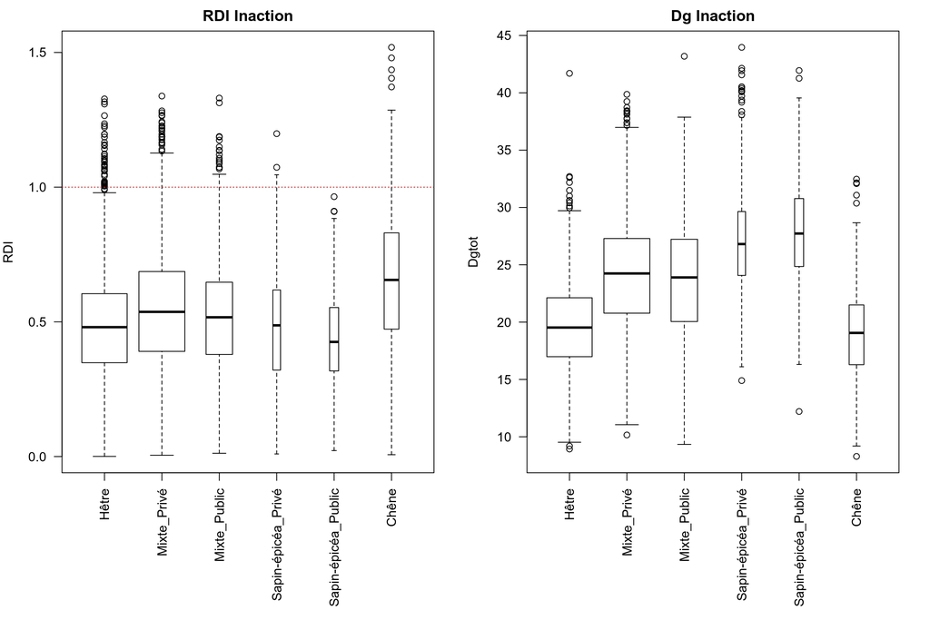

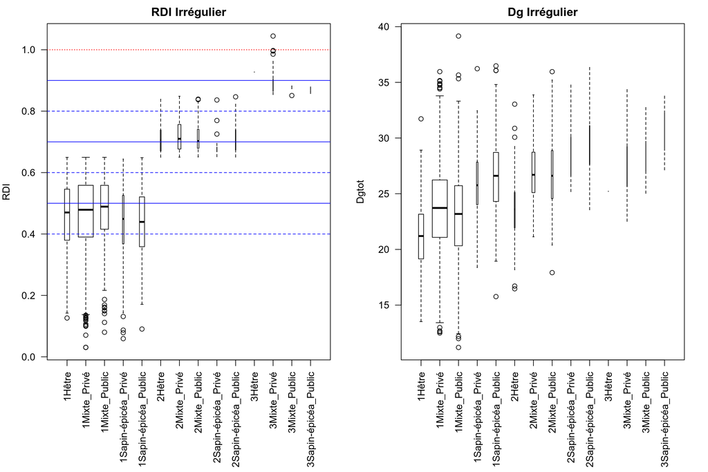

# 2 Simulations

On s’intéresse à une durée simulée de 30 années.

Dans le cas de la coupe rase, SIMMEM répète à chaque intervalle les valeurs du dernier volume exploité dans le fichier de sortie. Les valeurs en doublon sont enlevées du tableau de résultats. La dernière année simulée, aucune exploitation n’est réalisée, les valeurs de cette année sont enlevées.

Dans le fichier de sortie de SIMEMM, une ligne par année est indiquée. La première année reprend les valeurs initiales. Une intervention est éventuellement déclenchée dès la première année. Ce sont donc les caractéristiques du peuplement avant intervention qui sont indiquées. Les caractéristiques du peuplement après intervention ne sont pas disponibles, la ligne suivante présentant les caractéristiques du peuplement après intervention éventuelle et croissance du peuplement pendant la période de simulation suivante.

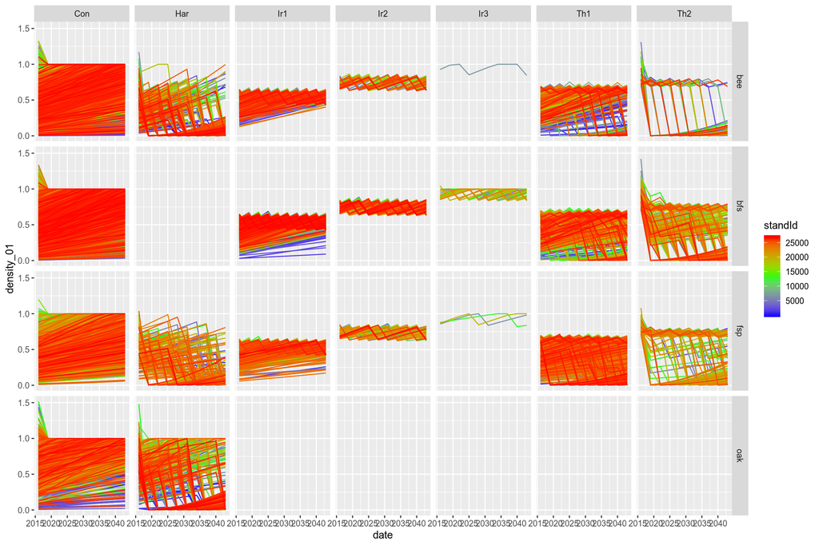